# Module-6

Nicole Merullo

2023-09-16

## Some useful procedures for exploratory data analysis for univariate data

### Challenge 1

Using summary() to get an overview of data from each column in a given data frame Includes (for numeric data): 1. minimum 2. 25th percentile 3. median 4. mean 5. 75th percentile 6 maximum 7. count of NAs (missing values) For Factors: 1. Count of each factor level (how many 1s, 2s, 3s)

First load in the file

```r
f <- "~/Documents/BU/AN_588/AN588-Modules-nmer/country-data-2016.csv"
d <- read.csv(f, header = TRUE, sep = ",", stringsAsFactor = FALSE)
head(d)
```

```
##          country population    area                      govt_form birthrate
## 1    Afghanistan   32564342  652230               islamic republic      38.6
## 2        Albania    3029278   28748                       republic      12.9
## 3        Algeria   39542166 2381741                       republic      23.7
## 4 American Samoa      54343     199 territory of the United States      22.9
## 5        Andorra      85580     468        constitutional monarchy       8.1
## 6         Angola   19625353 1246700                       republic      38.8
##   deathrate life_expect mammals birds reptiles amphibians fishes mollucs
## 1      13.9        50.9      11    17        1          1      5       0
## 2       6.6        78.1       3    10        4          2     44      49
## 3       4.3        76.6      14    14        8          3     40      10
## 4       4.8        75.1       1     8        6          0     12       5
## 5       7.0        82.7       2     2        1          0      0       3
## 6      11.5        55.6      17    26        5          0     51       5
##   other_inverts plants fungi_protists
## 1             2      5              0
## 2            13      0              0
## 3            26     18              0
## 4            59      1              0
## 5             4      0              0
## 6             4     34              0
```

Now use summary()

```r
summary(d)
```

```
##    country            population             area           govt_form
##  Length:248         Min.   :3.000e+01   Min.   :       0   Length:248
##  Class :character   1st Qu.:2.991e+05   1st Qu.:    1769   Class :character
##  Mode  :character   Median :4.912e+06   Median :   69700   Mode  :character
##                     Mean   :2.999e+07   Mean   :  610952
##                     3rd Qu.:1.803e+07   3rd Qu.:  398754
##                     Max.   :1.367e+09   Max.   :17098242
##                     NA's   :6           NA's   :1
##    birthrate       deathrate      life_expect       mammals
##  Min.   : 0.00   Min.   : 0.00   Min.   :49.80   Min.   :  0.00
##  1st Qu.:11.40   1st Qu.: 5.65   1st Qu.:67.40   1st Qu.:  3.00
##  Median :16.40   Median : 7.40   Median :74.70   Median :  8.00
##  Mean   :18.95   Mean   : 7.61   Mean   :72.19   Mean   : 13.85
##  3rd Qu.:24.35   3rd Qu.: 9.40   3rd Qu.:78.40   3rd Qu.: 15.00
##  Max.   :45.50   Max.   :14.90   Max.   :89.50   Max.   :188.00
##  NA's   :17      NA's   :17      NA's   :19      NA's   :3
##      birds           reptiles         amphibians          fishes
##  Min.   :  0.00   Min.   :  0.000   Min.   :  0.000   Min.   :  0.00
##  1st Qu.:  6.00   1st Qu.:  2.000   1st Qu.:  0.000   1st Qu.: 11.00
##  Median : 12.00   Median :  5.000   Median :  0.000   Median : 25.00
##  Mean   : 17.82   Mean   :  8.331   Mean   :  9.849   Mean   : 32.84
##  3rd Qu.: 19.00   3rd Qu.:  8.000   3rd Qu.:  4.000   3rd Qu.: 43.00
##  Max.   :165.00   Max.   :139.000   Max.   :215.000   Max.   :249.00
##  NA's   :3        NA's   :3         NA's   :3         NA's   :3
##     mollucs       other_inverts        plants        fungi_protists
##  Min.   :  0.00   Min.   :  0.00   Min.   :   0.00   Min.   : 0.0000
##  1st Qu.:  0.00   1st Qu.:  3.00   1st Qu.:   2.00   1st Qu.: 0.0000
##  Median :  1.00   Median : 11.00   Median :  10.00   Median : 0.0000
##  Mean   :  9.62   Mean   : 32.57   Mean   :  60.78   Mean   : 0.6082
##  3rd Qu.:  6.00   3rd Qu.: 33.00   3rd Qu.:  44.00   3rd Qu.: 0.0000
##  Max.   :301.00   Max.   :340.00   Max.   :1856.00   Max.   :12.0000
##  NA's   :3        NA's   :3        NA's   :3         NA's   :3
```

Let’s check out the names of the columns

```r
names(d)
```

```
##  [1] "country"        "population"     "area"           "govt_form"
##  [5] "birthrate"      "deathrate"      "life_expect"    "mammals"
##  [9] "birds"          "reptiles"       "amphibians"     "fishes"
## [13] "mollucs"        "other_inverts"  "plants"         "fungi_protists"
```

#### What are the median **area** and **population size** of all countries in the data set?

This is given in the summary so I can look back at the output and read it. The area median is 69700 The population median is 4.912e+06 (or 4,912,000)

To try pulling this more cleanly I can try the following using summary()

```r
popsumm <- summary(d$population)
popsumm
```

```
##      Min.   1st Qu.    Median      Mean   3rd Qu.      Max.      NA's
## 3.000e+01 2.991e+05 4.912e+06 2.999e+07 1.803e+07 1.367e+09         6
```

```r
areasumm <- summary(d[3])
areasumm
```

```
##       area
##  Min.   :       0
##  1st Qu.:    1769
##  Median :   69700
##  Mean   :  610952
##  3rd Qu.:  398754
##  Max.   :17098242
##  NA's   :1
```

```r
popsumm[3]
```

```
##  Median
## 4911766
```

```r
areasumm[3]
```

```
## [1] "Median :   69700  "
```

I used two different indexing/subsetting notations to create new objects that were then indexed again for just the median.

Because the columns are named, the $ notation can be used before the name of the column which returns a ‘summaryDefault’ structure. When that is indexed for the third position (median), it returns a table.

I used bracket notation for area summary which output a table. I indexed the table for the third position which returned a character vector.

I am not sure there is anything meaningful to these distinctions but might be useful in the future.

Now I will try using the median() function. na.rm is set to TRUE to remove the NA values from being considered.

```r
median(d$population, na.rm = TRUE)
```

```
## [1] 4911766
```

```r
median(d$area, na.rm = TRUE)
```

```
## [1] 69700
```

Ok, this is way less clunky than the multiple functions I had to use for summary to make it as clean as this. The $ notation was the only one that worked for this one. [] notation did not work and returned an error “Error in median.default(d[3], na.rm = TRUE) : need numeric data”

#### Create a new pop_density variable in your data frame which is population / area. What are the 10 most dense countries? The 10 least dense?

First, I am using cbind() to add the pop_density variable as column and saving that into the d variable. I am using str() to ensure that the class of pop_density is numbers.

```r
pop_density <- d$population/d$area
d <- cbind(d, pop_density)
head(d)
```

```
##          country population    area                      govt_form birthrate
## 1    Afghanistan   32564342  652230               islamic republic      38.6
## 2        Albania    3029278   28748                       republic      12.9
## 3        Algeria   39542166 2381741                       republic      23.7
## 4 American Samoa      54343     199 territory of the United States      22.9
## 5        Andorra      85580     468        constitutional monarchy       8.1
## 6         Angola   19625353 1246700                       republic      38.8
##   deathrate life_expect mammals birds reptiles amphibians fishes mollucs
## 1      13.9        50.9      11    17        1          1      5       0
## 2       6.6        78.1       3    10        4          2     44      49
## 3       4.3        76.6      14    14        8          3     40      10
## 4       4.8        75.1       1     8        6          0     12       5
## 5       7.0        82.7       2     2        1          0      0       3
## 6      11.5        55.6      17    26        5          0     51       5
##   other_inverts plants fungi_protists pop_density
## 1             2      5              0    49.92770
## 2            13      0              0   105.37352
## 3            26     18              0    16.60221
## 4            59      1              0   273.08040
## 5             4      0              0   182.86325
## 6             4     34              0    15.74184
```

```r
str(d)
```

```
## 'data.frame':    248 obs. of  17 variables:
##  $ country       : chr  "Afghanistan" "Albania" "Algeria" "American Samoa" ...
##  $ population    : int  32564342 3029278 39542166 54343 85580 19625353 16418 NA 92436 43431886 ...
##  $ area          : num  652230 28748 2381741 199 468 ...
##  $ govt_form     : chr  "islamic republic" "republic" "republic" "territory of the United States" ...
##  $ birthrate     : num  38.6 12.9 23.7 22.9 8.1 38.8 12.7 NA 15.9 16.6 ...
##  $ deathrate     : num  13.9 6.6 4.3 4.8 7 11.5 4.6 NA 5.7 7.3 ...
##  $ life_expect   : num  50.9 78.1 76.6 75.1 82.7 55.6 81.3 NA 76.3 77.7 ...
##  $ mammals       : int  11 3 14 1 2 17 1 2 2 37 ...
##  $ birds         : int  17 10 14 8 2 26 0 4 1 50 ...
##  $ reptiles      : int  1 4 8 6 1 5 8 0 6 15 ...
##  $ amphibians    : int  1 2 3 0 0 0 0 0 0 30 ...
##  $ fishes        : int  5 44 40 12 0 51 29 0 29 39 ...
##  $ mollucs       : int  0 49 10 5 3 5 0 0 0 0 ...
##  $ other_inverts : int  2 13 26 59 4 4 10 0 11 14 ...
##  $ plants        : int  5 0 18 1 0 34 4 0 4 70 ...
##  $ fungi_protists: int  0 0 0 0 0 0 0 0 0 0 ...
##  $ pop_density   : num  49.9 105.4 16.6 273.1 182.9 ...
```

Next, I am using order() to ifnd the top 10 most dense countries and saving them to a new variable d_topdense.

```r
d_mostdense <- order(d[, "pop_density"], na.last = TRUE, decreasing = TRUE)
d_mostdense[1:10]
```

```
##  [1] 130 145  97 199  99  84  17 135 137  24
```

Doing this method only gives me the INDEXED POSITIONS of the countries (the row numbers) as a number vector. d_topdense is saved as an integer vector (just to prove a point). What I really want to see is a variable saved as a table or data frame so that I can look at the whole thing.

If I used order() inside index brackets I will be indexing just the ordered table.

```r
d_mostdense <- d[order(d$pop_density, na.last = TRUE, decreasing = TRUE), ]
d_mostdense[1:10, ]
```

```
##                     country population   area
## 130                   Macau     592731   28.0
## 145                  Monaco      30535    2.0
## 97  Holy See (Vatican City)        842    0.1
## 199               Singapore    5674472  697.0
## 99                Hong Kong    7141106 1108.0
## 84                Gibraltar      29258    7.0
## 17                  Bahrain    1346613  760.0
## 135                Maldives     393253  298.0
## 137                   Malta     413965  316.0
## 24                  Bermuda      70196   54.0
##                                  govt_form birthrate deathrate life_expect
## 130 special administrative region of China       8.9       4.2        84.5
## 145                constitutional monarchy       6.7       9.2        89.5
## 97                                monarchy        NA        NA          NA
```

[output cut: 29 more lines]

I had some errors (undefined columns selected) with this until I googled the error and found I needed to add a comma after the closing parenthesis and a space following that. I think this is because we are subsetting the rows in the first half of the brackets and we are ordering those by population density. We are not doing anything with the columns so that is left blank. R needs to know I am not doing anything with the columns even if that is leaving it blank with a comma and a space.

The same thing happens when I subset the variable d_mostdense for the first ten. Those are just the first ten rows, and I need to leave the column coordinate blank. If I do put in a coordinate for the column, it returns a integer vector of the values from the column (such as all of the density values but nothing else about them). Going back to the previous attempt at this, if I did add a column coordinate to that final line of code, I get an error saying incorrect number of dimensions. This is because d_mostdense was only an integer vector in that case and not a data frame, so it only has one dimension.

Attempting the same thing but with the least dense countries:

```r
d_leastdense <- d[order(d$pop_density, na.last = TRUE, decreasing = FALSE), ]
d_leastdense[1:10, ]
```

```
##                                      country population    area
## 206 South Georgia and South Sandwich Islands         30    3903
## 86                                 Greenland      57733 2166086
## 70                          Falkland Islands       3361   12173
## 175                         Pitcairn Islands         48      47
## 146                                 Mongolia    2992908 1564116
## 245                           Western Sahara     570866  266000
## 76                             French Guiana     181000   83534
## 152                                  Namibia    2212307  824292
## 13                                 Australia   22751014 7741220
## 101                                  Iceland     331918  103000
##                        govt_form birthrate deathrate life_expect mammals birds
## 206   British overseas territory        NA        NA          NA       3     6
## 86  autonomous region of Denmark      14.5       8.5        72.1       9     3
## 70    British overseas territory        NA        NA          NA       4     9
```

[output cut: 29 more lines]

#### Extract data from the 20 largest countries into a new variable. What are the median area and population size of these countries?

A country can be large by population or by area. I will do it by both I guess.

By area first:

```r
d_bigarea <- d[order(d$area, na.last = TRUE, decreasing = TRUE), ]
d_bigarea <- d_bigarea[1:20, ]
d_bigarea
```

```
##                              country population     area
## 182                           Russia  142423773 17098242
## 8                         Antarctica         NA 14000000
## 39                            Canada   35099836  9984670
## 239                              USA  321368864  9826675
## 45                             China 1367485388  9596960
## 30                            Brazil  204259812  8514877
## 13                         Australia   22751014  7741220
## 102                            India 1251695584  3287263
## 10                         Argentina   43431886  2780400
## 115                       Kazakhstan   18157122  2724900
## 3                            Algeria   39542166  2381741
## 58  Democratic Republic of the Congo   79375136  2344858
## 86                         Greenland      57733  2166086
## 194                     Saudi Arabia   27752316  2149690
```

[output cut: 69 more lines]

```r
median(d_bigarea$population, na.rm = TRUE)
```

```
## [1] 43431886
```

```r
median(d_bigarea$area, na.rm = TRUE)
```

```
## [1] 2553320
```

By population:

```r
d_bigpop <- d[order(d$population, na.last = TRUE, decreasing = TRUE), ]
d_bigpop <- d_bigpop[1:20, ]
d_bigpop
```

```
##                              country population     area
## 45                             China 1367485388  9596960
## 102                            India 1251695584  3287263
## 239                              USA  321368864  9826675
## 103                        Indonesia  255993674  1904569
## 30                            Brazil  204259812  8514877
## 167                         Pakistan  199085847   796095
## 160                          Nigeria  181562056   923768
## 18                        Bangladesh  168957745   143998
## 182                           Russia  142423773 17098242
## 112                            Japan  126919659   377915
## 143                           Mexico  121736809  1964375
## 174                      Philippines  100998376   300000
## 69                          Ethiopia   99465819  1104300
## 243                         Viet Nam   94348835   331210
```

[output cut: 69 more lines]

```r
median(d_bigpop$population, na.rm = TRUE)
```

```
## [1] 124328234
```

```r
median(d_bigpop$area, na.rm = TRUE)
```

```
## [1] 1052875
```

#### Extract data from all countries beginning with the letters “A” through “F”. What are the mean area and population size of these countries?

Will need to use grep() for this which finds a pattern (in this case letters A through F) in a given character vector (in this case the column Countries). Note that note every column is a character class so this would not work on every column.

The extraction is similar to the order() extraction where the function is placed inside the bracket notation as the row dimension coordinate, and the column dimension is left blank.

```r
alphabet <- d[grep("^[A-F]", d$country), ]
summary(alphabet)
```

```
##    country            population             area           govt_form
##  Length:78          Min.   :5.960e+02   Min.   :      14   Length:78
##  Class :character   1st Qu.:2.991e+05   1st Qu.:    4066   Class :character
##  Mode  :character   Median :4.785e+06   Median :   51148   Mode  :character
##                     Mean   :3.507e+07   Mean   :  918248
##                     3rd Qu.:1.469e+07   3rd Qu.:  466498
##                     Max.   :1.367e+09   Max.   :14000000
##                     NA's   :4
##    birthrate       deathrate       life_expect       mammals
##  Min.   : 0.00   Min.   : 0.000   Min.   :49.80   Min.   : 0.0
##  1st Qu.:11.65   1st Qu.: 5.850   1st Qu.:68.75   1st Qu.: 3.0
##  Median :15.90   Median : 7.700   Median :75.50   Median : 7.0
##  Mean   :18.77   Mean   : 7.861   Mean   :72.25   Mean   :13.4
##  3rd Qu.:23.30   3rd Qu.: 9.500   3rd Qu.:78.40   3rd Qu.:14.0
##  Max.   :42.00   Max.   :14.400   Max.   :82.70   Max.   :81.0
##  NA's   :7       NA's   :7        NA's   :7
##      birds           reptiles        amphibians         fishes
##  Min.   :  0.00   Min.   : 0.000   Min.   :  0.00   Min.   :  0.00
##  1st Qu.:  6.00   1st Qu.: 2.000   1st Qu.:  0.00   1st Qu.: 10.00
##  Median : 11.00   Median : 5.000   Median :  0.00   Median : 24.50
##  Mean   : 18.62   Mean   : 7.397   Mean   : 11.86   Mean   : 29.54
##  3rd Qu.: 18.00   3rd Qu.: 8.000   3rd Qu.:  3.00   3rd Qu.: 41.50
##  Max.   :165.00   Max.   :43.000   Max.   :215.00   Max.   :133.00
##
##     mollucs       other_inverts        plants        fungi_protists
##  Min.   :  0.00   Min.   :  0.00   Min.   :   0.00   Min.   :0.0000
##  1st Qu.:  0.00   1st Qu.:  4.00   1st Qu.:   2.25   1st Qu.:0.0000
##  Median :  1.00   Median : 11.00   Median :  10.00   Median :0.0000
##  Mean   : 10.17   Mean   : 23.63   Mean   :  70.64   Mean   :0.6026
##  3rd Qu.:  5.00   3rd Qu.: 25.25   3rd Qu.:  41.75   3rd Qu.:0.0000
##  Max.   :174.00   Max.   :340.00   Max.   :1856.00   Max.   :8.0000
##
##   pop_density
##  Min.   :   0.2761
##  1st Qu.:  24.5932
##  Median :  75.0297
##  Mean   : 162.4785
##  3rd Qu.: 140.7140
##  Max.   :1771.8592
##  NA's   :4
```

```r
mean(alphabet$population, na.rm = TRUE)
```

```
## [1] 35065172
```

```r
mean(alphabet$area, na.rm = TRUE)
```

```
## [1] 918247.7
```

Both summary() and mean() will get us the data requested which is mean area and population size of these 78 subset countries.

### Challenge 2

Using Boxplots and Barplots

Boxplots: boxplot() functions returns a box and whiskers visual of the summary data from a column plus the outliers. Does not like nonnumeric data so must be used with specific columns using bracket of $ notation

Barplots: barplot() function returns a bar plot with bar height proportional to the value of the variable. dotchart() provides similar. Barplots are good for crude data

#### Make boxplots of the raw population and area data, then do the same after log() transforming these variables.

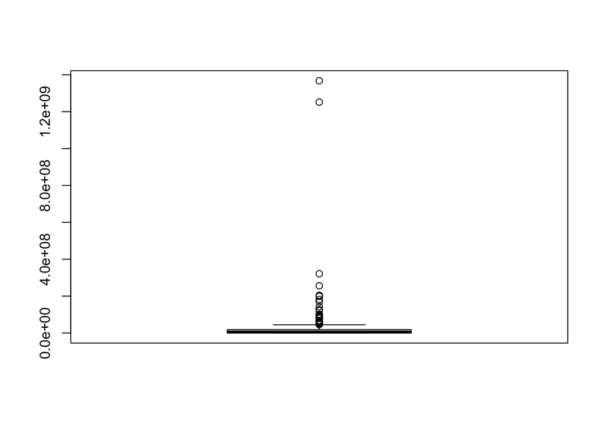

```r
boxplot(d$population)
```

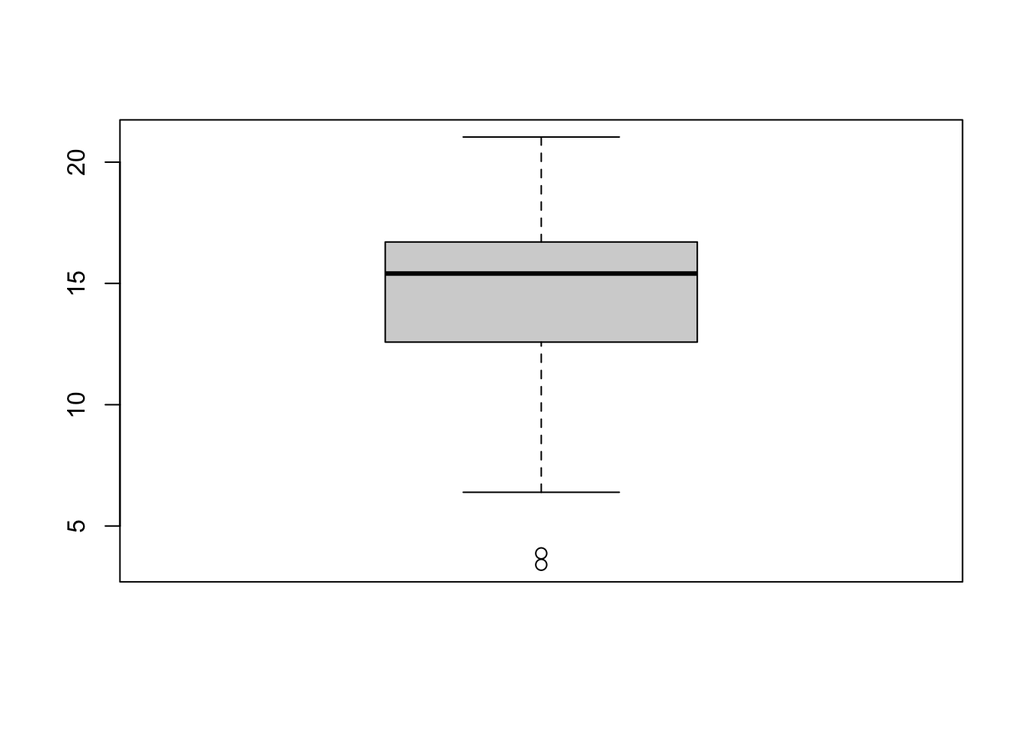

```r
boxplot(log(d$population))
```

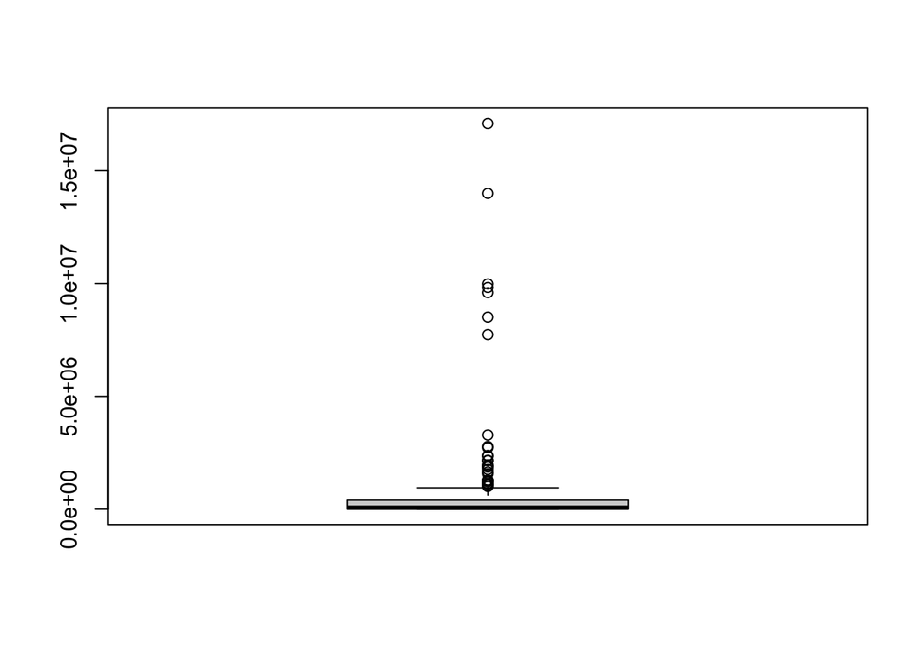

```r
boxplot(d$area)
```

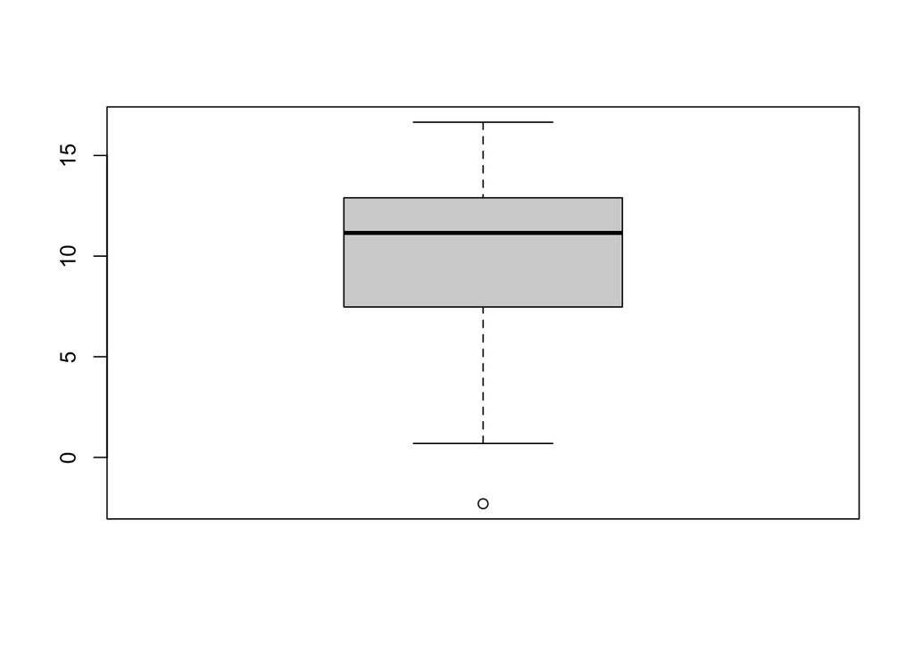

```r
boxplot(log(d$area))
```

Using log makes it so much more readable

Using par() with mfrow (filled in by row) as the argument will arrange the boxplots accordingly:

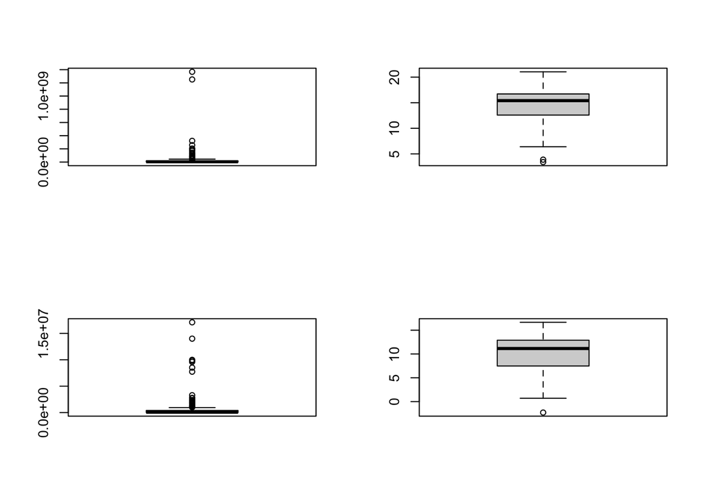

```r
par(mfrow = c(2,2))
boxplot(d$population)
boxplot(log(d$population))
boxplot(d$area)
boxplot(log(d$area))
```

And now the barplots of population and area:

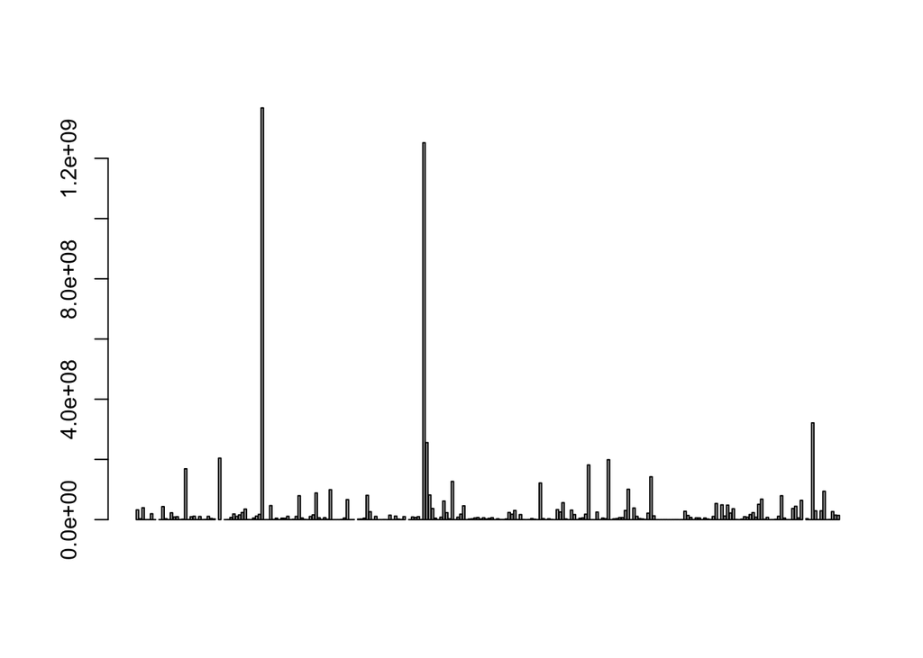

```r
barplot(d$population)
```

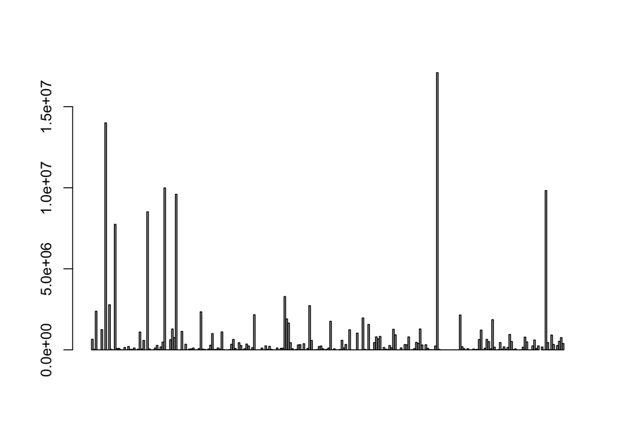

```r
barplot(d$area)
```

These plots do not mean much without labels.

### Challenge 3

#### Histograms

The hist() function returns a histogram showing the complete empirical distribution of the data in binned categories, which is useful for checking skewness of the data, symmetry, multi-modality, etc. Setting the argument freq=FALSE will scale the Y axis to represent the proportion of observations falling into each bin rather than the count.

Make histograms of the log() transformed population and area data from the Country-Data-2016 file. Explore what happens if you set freq=FALSE versus the default of freq=TRUE. Try looking at other variables as well.

First attempt will just be with inputting the data to be turned into a histogram with no modifications to the variables.

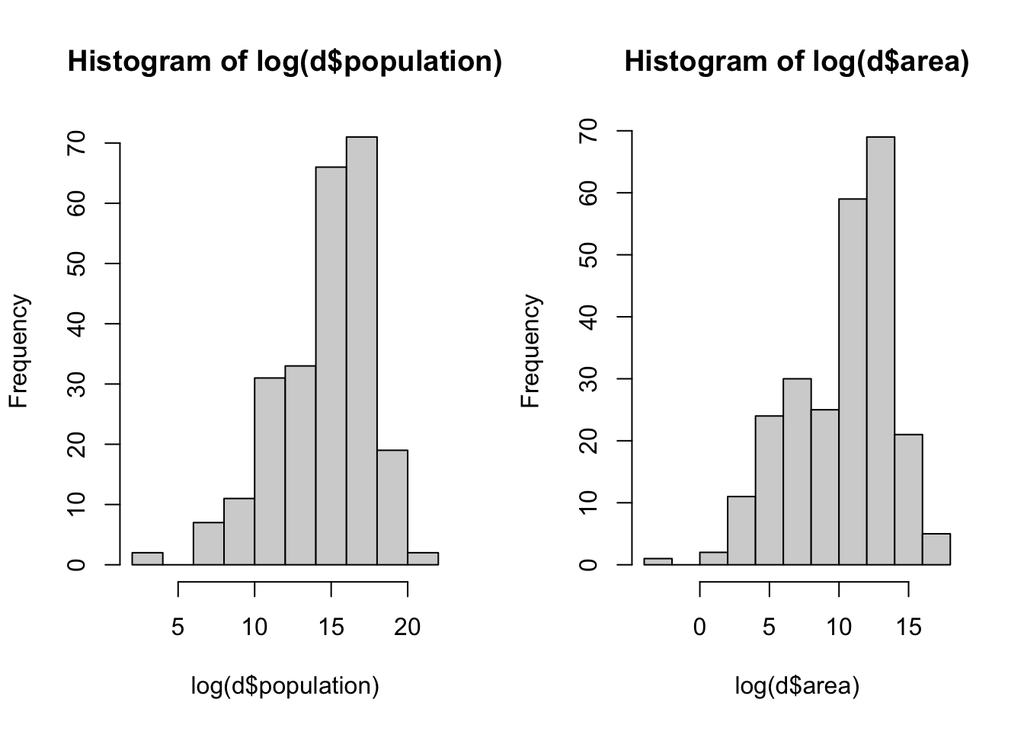

```r
par(mfrow = c(1, 2))
hist(log(d$population))
hist(log(d$area))
```

Frequency defaults to true, which is the y-axis. This is showing how frequent each population is and how frequent each area is (grouped up into bars that are equi-spaced by breaks). Breaks are another argument that can be modified.

If I use attach() then I don’t need to use $ notation anymore and R will search just for the name of the column I am making a plot of

This time I will set freq to false which will make the y axis looking at density instead of frequency.I will also name the axes and the plot.

```r
attach(d)
```

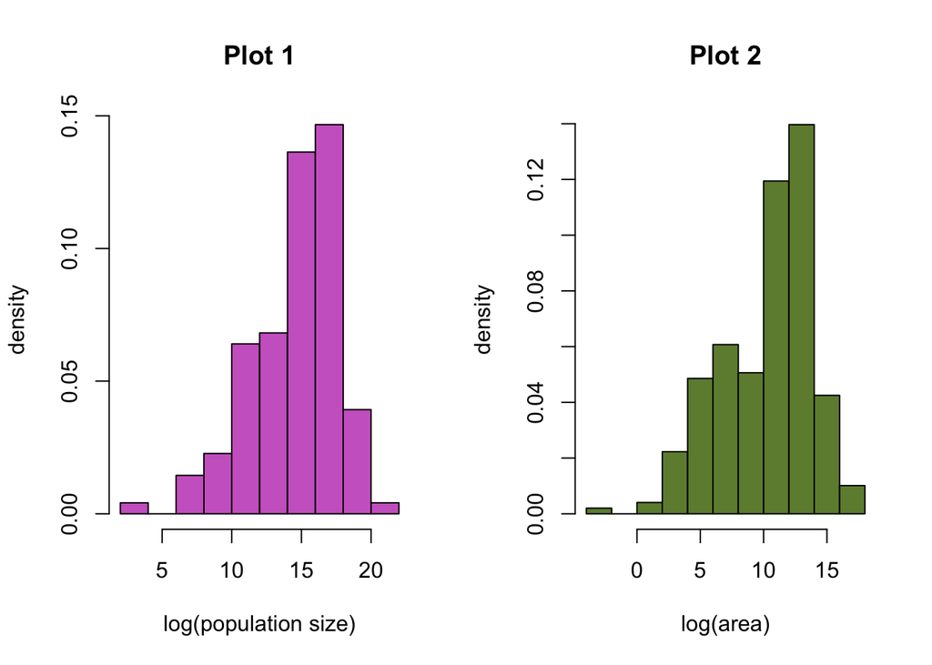

```r
par(mfrow = c(1, 2))
hist(log(population), freq = FALSE, col = "orchid3", main = "Plot 1", xlab = "log(population size)", ylab = "density")
hist(log(area), freq = FALSE, col = "darkolivegreen4", main = "Plot 2", xlab = "log(area)", ylab = "density")
```

The y limits are not the same like they were with the freq=true histograms. That can be changed with an argument modification.

adding vertical lines showing mean of x axis.

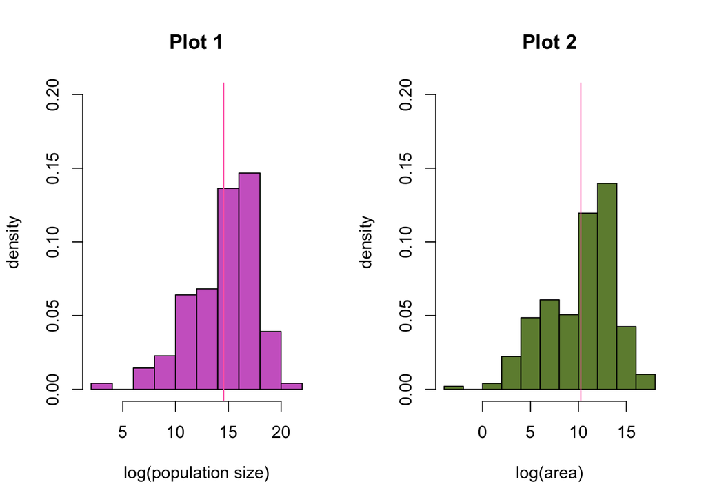

```r
par(mfrow = c(1, 2))
hist(log(population), freq = FALSE, col = "orchid3", main = "Plot 1", xlab = "log(population size)", ylab = "density", ylim = c(0, 0.2))
abline(v = mean(log(population), na.rm = TRUE), col = "hotpink")
hist(log(area), freq = FALSE, col = "darkolivegreen4", main = "Plot 2", xlab = "log(area)", ylab = "density", ylim = c(0, 0.2))
abline(v = mean(log(area), na.rm = TRUE), col = "hotpink")
```

#### Density Plot

The density() function computes a non-parametric estimate of the distribution of a variable, which can be combined with plot() to also yield a graphical view of the distribution of the data. If your data have missing values, then you need to add the argument na.rm=TRUE to the density() function. To superimpose a density() curve on a histogram, you can use the lines(density()) function.

It kind of smooths out the histogram

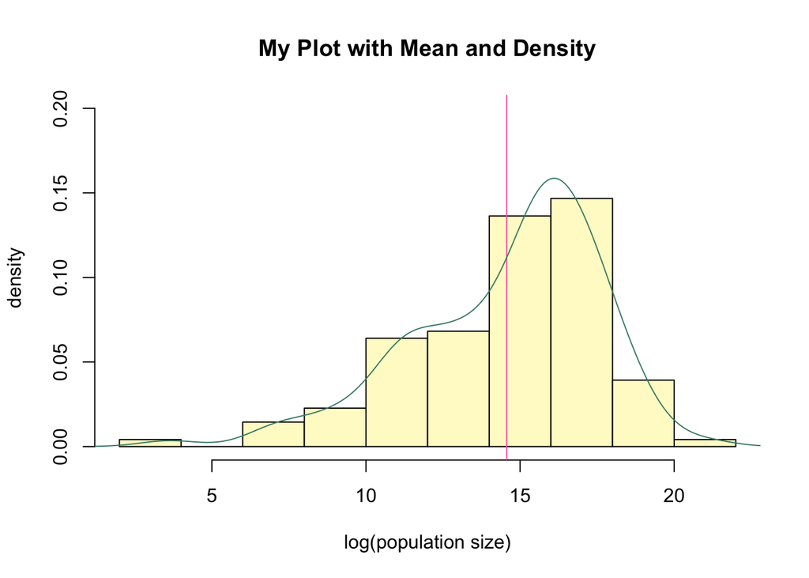

```r
par(mfrow = c(1, 1))  # set up one panel and redraw the log(population) histogram
hist(log(population), freq = FALSE, col = "lemonchiffon", main = "My Plot with Mean and Density",
    xlab = "log(population size)", ylab = "density", ylim = c(0, 0.2))
abline(v = mean(log(population), na.rm = TRUE), col = "hotpink")
lines(density(log(population), na.rm = TRUE), col = "aquamarine4")
```

```r
detach(d)
```

### Challenge 4

Tables : the table() function can be used to summarize counts and proportions for categorical variables in your dataset.

Using the table() function, find what is the most common form of government in the Country-Data-2016 dataset. How many countries have that form?

```r
table(d$govt_form)
```

```
##
##                       absolute monarchy                       autonomous region
##                                       2                                       1
##            autonomous region of Denmark             autonomous region of France
##                                       2                                       1
##            autonomous region of Morocco     autonomous territory of New Zealand
##                                       1                                       2
## autonomous territory of the Netherlands              British overseas territory
##                                       3                                      12
##                 constitutional monarchy                        federal republic
##                                      33                                       3
##                              federation         foreign-administrated territory
##                                       1                                       1
##                        islamic republic      islamic-socialist peoples republic
##                                       3                                       1
##                                monarchy            overseas community of France
##                                       6                                       2
##            overseas territory of France                 parliamentary democracy
##                                       7                                       4
##          parliamentary federal republic                  parliamentary monarchy
##                                       2                                       5
##                  parliamentary republic                        peoples republic
##                                       1                                       1
##           presidential federal republic                                republic
##                                       7                                     127
##                      socialist republic  special administrative region of China
##                                       3                                       2
##                  territory of Australia                     territory of France
##                                       4                                       1
##                territory of New Zealand                     territory of Norway
##                                       1                                       2
##            territory of the Netherlands          territory of the United States
##                                       1                                       5
```

Using just the table function returns a list of all of the observations in the column requested and how many of each (e.g., there are 33 observations of constitutional monarchy)

```r
sort(table(d$govt_form), decreasing = TRUE)
```

```
##
##                                republic                 constitutional monarchy
##                                     127                                      33
##              British overseas territory            overseas territory of France
##                                      12                                       7
##           presidential federal republic                                monarchy
##                                       7                                       6
##                  parliamentary monarchy          territory of the United States
##                                       5                                       5
##                 parliamentary democracy                  territory of Australia
##                                       4                                       4
## autonomous territory of the Netherlands                        federal republic
##                                       3                                       3
##                        islamic republic                      socialist republic
##                                       3                                       3
##                       absolute monarchy            autonomous region of Denmark
##                                       2                                       2
##     autonomous territory of New Zealand            overseas community of France
##                                       2                                       2
##          parliamentary federal republic  special administrative region of China
##                                       2                                       2
##                     territory of Norway                       autonomous region
##                                       2                                       1
##             autonomous region of France            autonomous region of Morocco
##                                       1                                       1
##                              federation         foreign-administrated territory
##                                       1                                       1
##      islamic-socialist peoples republic                  parliamentary republic
##                                       1                                       1
##                        peoples republic                     territory of France
##                                       1                                       1
##                territory of New Zealand            territory of the Netherlands
##                                       1                                       1
```

Remember that order() returns the indexed position (as seen earlier when I tried using it not inside bracket notation). Sort() returns the vector in order.

**The most common form of government from the dataset is republic with 127 countries claiming that form.**

## Multivariate Data

### Challenge 5

Multiple boxplots or histograms can be laid out side-by-side or overlaid. For boxplots, the ~ operator can be read as “by”.

Read in the dataset KamilarAndCooperData, which contains a host of information from about 213 living primate species.

Spend some time exploring the data and then make boxplots of log(female body mass) ~ family. Try doing this with {base} graphics and then look at how we might do in in {ggplot2}, which provides a standard “grammar of graphics” (see the {ggplot2} documentation)

```r
f1 <- "~/Documents/BU/AN_588/AN588-Modules-nmer/KamilarAndCooperData.csv"
k <- read.csv(f1, header = TRUE, sep = ",", stringsAsFactor = FALSE)
head(k)
```

```
##               Scientific_Name          Family          Genus      Species
## 1 Allenopithecus_nigroviridis Cercopithecidae Allenopithecus nigroviridis
## 2         Allocebus_trichotis Cercopithecidae      Allocebus    trichotis
## 3           Alouatta_belzebul        Atelidae       Alouatta     belzebul
## 4             Alouatta_caraya        Atelidae       Alouatta       caraya
## 5            Alouatta_guariba        Atelidae       Alouatta      guariba
## 6           Alouatta_palliata        Atelidae       Alouatta     palliata
##   Brain_Size_Species_Mean Brain_Size_Female_Mean   Brain_size_Ref
## 1                   58.02                  53.70 Isler et al 2008
## 2                      NA                     NA
## 3                   52.84                  51.19 Isler et al 2008
## 4                   52.63                  47.80 Isler et al 2008
## 5                   51.70                  49.08 Isler et al 2008
## 6                   49.88                  48.04 Isler et al 2008
##   Body_mass_male_mean Body_mass_female_mean Mass_Dimorphism
```

[output cut: 62 more lines]

```r
summary(k)
```

```
##  Scientific_Name       Family             Genus             Species
##  Length:213         Length:213         Length:213         Length:213
##  Class :character   Class :character   Class :character   Class :character
##  Mode  :character   Mode  :character   Mode  :character   Mode  :character
##
##
##
##
##  Brain_Size_Species_Mean Brain_Size_Female_Mean Brain_size_Ref
##  Min.   :  1.63          Min.   :  1.66         Length:213
##  1st Qu.: 13.95          1st Qu.: 13.23         Class :character
##  Median : 61.45          Median : 57.20         Mode  :character
##  Mean   : 68.11          Mean   : 65.24
##  3rd Qu.: 88.48          3rd Qu.: 86.80
##  Max.   :491.27          Max.   :480.15
##  NA's   :42              NA's   :48
##  Body_mass_male_mean Body_mass_female_mean Mass_Dimorphism   Mass_Ref
##  Min.   :    31      Min.   :   30.0       Min.   :0.841   Length:213
##  1st Qu.:   865      1st Qu.:  835.5       1st Qu.:1.013   Class :character
##  Median :  4290      Median : 3039.0       Median :1.109   Mode  :character
##  Mean   :  8112      Mean   : 5396.5       Mean   :1.246
##  3rd Qu.:  7815      3rd Qu.: 6390.0       3rd Qu.:1.409
##  Max.   :170400      Max.   :97500.0       Max.   :2.688
##  NA's   :18          NA's   :18            NA's   :18
##  MeanGroupSize     AdultMales      AdultFemale     AdultSexRatio
##  Min.   : 1.00   Min.   : 0.900   Min.   : 1.000   Min.   : 0.500
##  1st Qu.: 4.00   1st Qu.: 1.000   1st Qu.: 1.000   1st Qu.: 1.000
##  Median : 7.80   Median : 1.500   Median : 2.900   Median : 1.450
##  Mean   :15.06   Mean   : 2.516   Mean   : 5.049   Mean   : 2.305
##  3rd Qu.:18.50   3rd Qu.: 3.100   3rd Qu.: 7.100   3rd Qu.: 2.770
##  Max.   :90.00   Max.   :16.000   Max.   :25.200   Max.   :15.600
##  NA's   :60      NA's   :68       NA's   :68       NA's   :84
##  Social_Organization_Ref InterbirthInterval_d   Gestation       WeaningAge_d
##  Length:213              Min.   : 144.5       Min.   : 59.99   Min.   :  40.0
##  Class :character        1st Qu.: 365.0       1st Qu.:142.00   1st Qu.: 122.4
##  Mode  :character        Median : 476.9       Median :165.04   Median : 237.7
##                          Mean   : 572.1       Mean   :163.47   Mean   : 310.0
##                          3rd Qu.: 741.4       3rd Qu.:180.75   3rd Qu.: 383.4
##                          Max.   :2007.5       Max.   :256.00   Max.   :1260.8
##                          NA's   :103          NA's   :75       NA's   :95
```

[output cut: 41 more lines]

```
##  Min.   : 9.00   Min.   : 3.00   Min.   : 4.00   Min.   : 0.900
##  1st Qu.:21.75   1st Qu.:14.93   1st Qu.:18.38   1st Qu.: 3.500
##  Median :33.30   Median :21.00   Median :30.48   Median : 5.400
##  Mean   :33.08   Mean   :21.67   Mean   :34.26   Mean   : 7.369
##  3rd Qu.:43.08   3rd Qu.:26.90   3rd Qu.:52.40   3rd Qu.:10.000
##  Max.   :63.90   Max.   :70.60   Max.   :78.50   Max.   :23.500
##  NA's   :141     NA's   :143     NA's   :143     NA's   :136
##  Activity_Budget_Ref
##  Length:213
##  Class :character
##  Mode  :character
##
##
##
##
```

```r
attach(k)
```

#### Boxplots

The column specified after the ~ goes on the X axis. This is non-numerical data otherwise it would not be able to be passed through the boxplot.

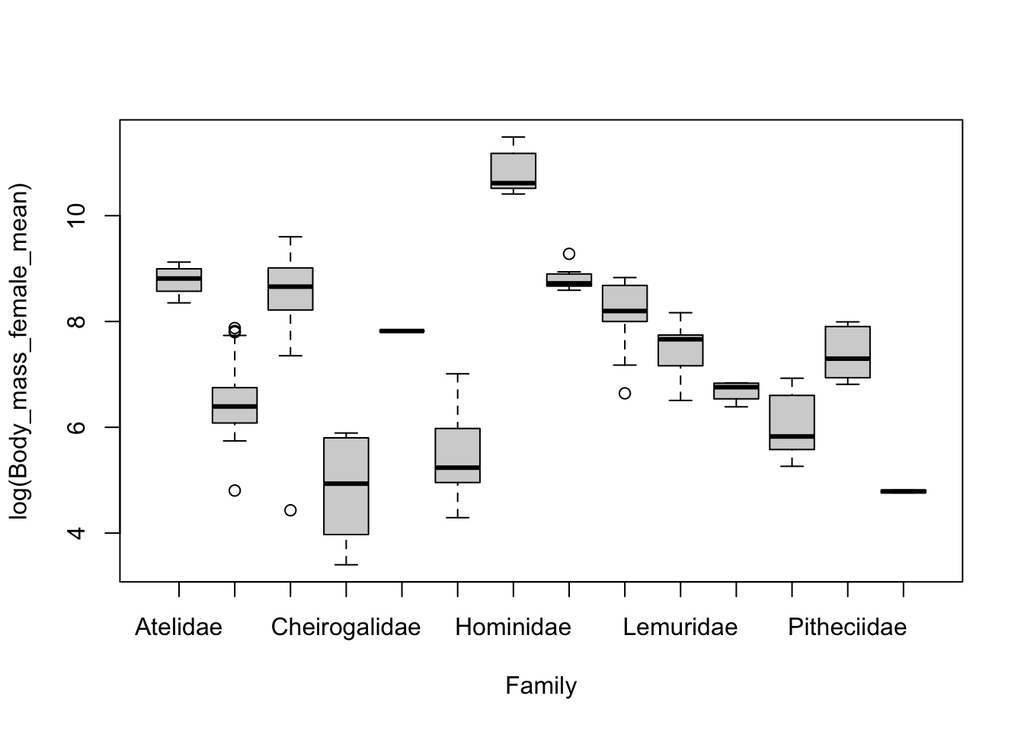

```r
boxplot(log(Body_mass_female_mean) ~ Family)
```

```r
detach(k)
```

The module instructions are: boxplot(log(Body_mass_female_mean) ~ Family, k) I do not see a difference adding the file variable at the end and I cannot find anything in the documentation for boxplot() for it.

Also in this plot not every family name is listed on the x axis.

#### ggplot2

With ggplot, we can add to the object little by little for ease of reading.

Here is a breakdown of the lines of code below 1. defining the variables 2. graph into a box plot 3. put x-axis names at 90deg to the axis 4. rename y axis 5. run the graph

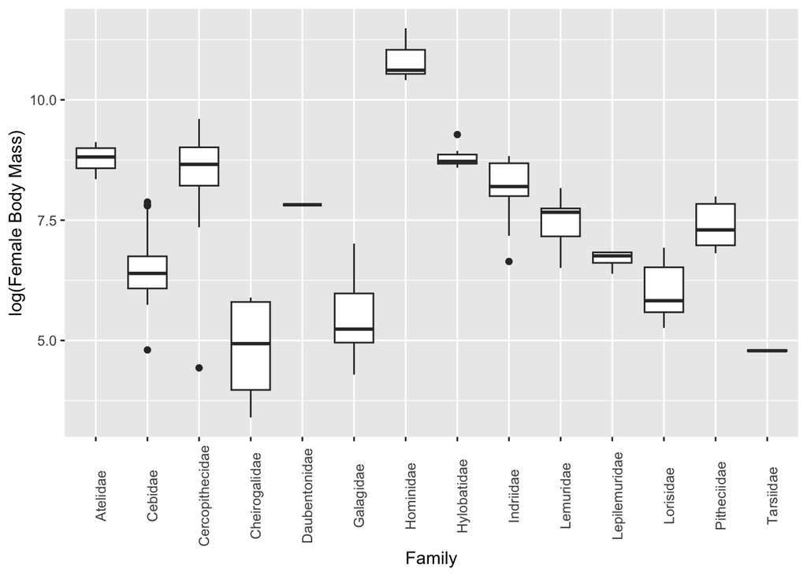

```r
p <- ggplot(data = k, aes(x = Family, y = log(Body_mass_female_mean)))
p <- p + geom_boxplot()
p <- p + theme(axis.text.x = element_text(angle = 90))
p <- p + ylab("log(Female Body Mass)")
p
```

### Challenge 6

Scatterplots with base vs ggplot2

Scatterplots : Scatterplots are a natural tool for visualizing two continuous variables and can be made easily with the plot(x=XXX, y=YYY) function in {base} graphics (where XXX* and YYY** denote the names of the two variables you wish to plot). Transformations of the variables, e.g., log or square-root (sqrt()), may be necessary for effective visualization.

Again using data from the KamilarAndCooperData dataset, plot the relationship between female body size and female brain size. Then, play with log transforming the data and plot again.

#### Base Graphics

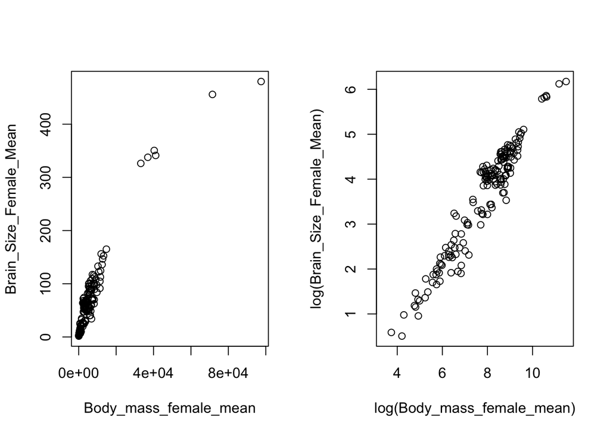

```r
attach(k)
par(mfrow = c(1, 2))
plot(x = Body_mass_female_mean, y = Brain_Size_Female_Mean)
plot(x = log(Body_mass_female_mean), y = log(Brain_Size_Female_Mean))
```

```r
detach(k)
```

Did this to show the difference between no log and with log. With log is like zooming in and getting a better view of the data.

The former would be really good for showing the exceptionalism of apes (and capuchins) but the latter would be better at looking at everyone.

#### ggplot2

Following similar steps from the boxplot- will do a scatterplot with the same data as above 1. defining the variables and data and color coding the plot points by Family column 2. modify the axis labels (this was step 4 before) 3. make the scatterplot (step 2 before) 4. modify the legend at the bottom (kind of equivalent to step 3 before) and legend title is blank 4. run the graph

Must turn the Family column into a factor!! This is important because otherwise it will fail; this one was just a character vector before

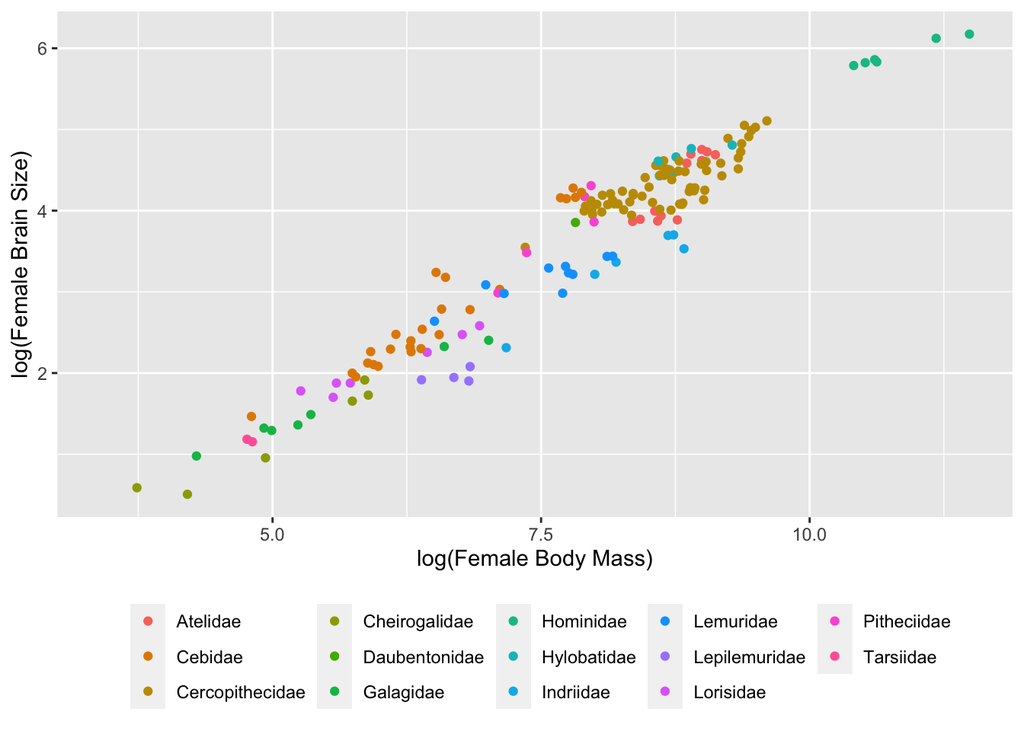

```r
p1 <- ggplot(data = k, aes(x = log(Body_mass_female_mean), y = log(Brain_Size_Female_Mean), color = factor(Family)))
p1 <- p1 + xlab("log(Female Body Mass)") + ylab("log(Female Brain Size)")
p1 <- p1 + geom_point()
p1 <- p1 + theme(legend.position = "bottom", legend.title = element_blank())
p1
```

Grid for faceting by a grouping variable

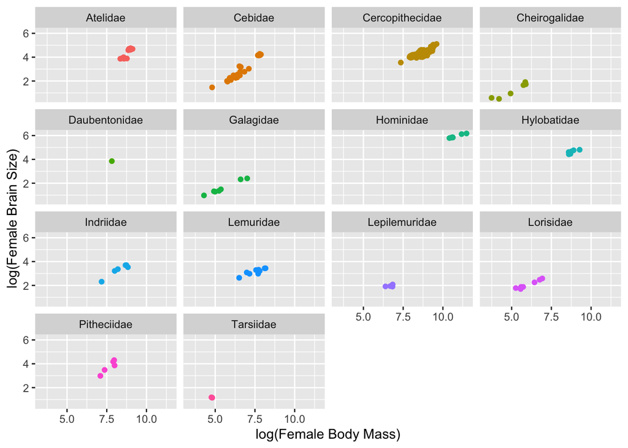

```r
p1 <- p1 + facet_wrap(~Family, ncol = 4)
p1 <- p1 + theme(legend.position = "none")
p1
```

And then add regression lines. These could suggest different evolutionary relationships between brain size and body size

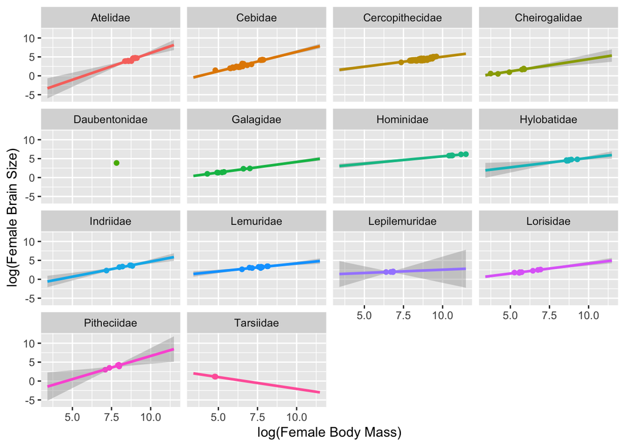

```r
p1 <- p1 + geom_smooth(method = "lm", fullrange = TRUE)
p1
```

### Challenge 7

Make my own scatterplot!

This one is average species brain size by max longevity visualized by family

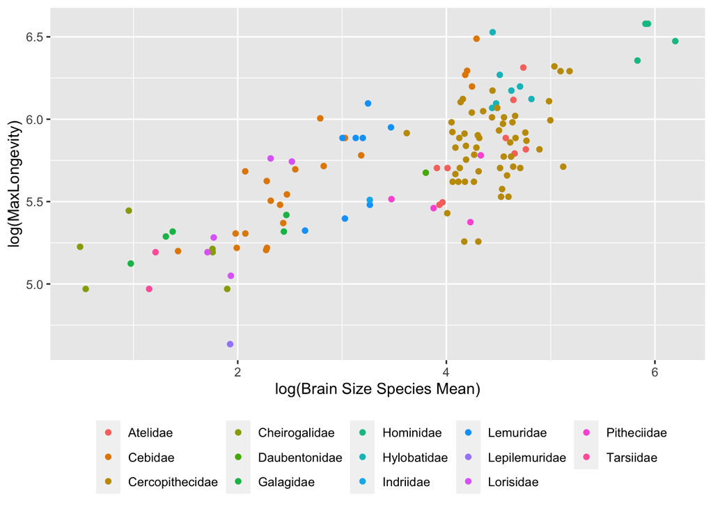

```r
p2 <- ggplot(data = k, aes(x = log(Brain_Size_Species_Mean), y = log(MaxLongevity_m), color = factor(Family)))
p2 <- p2 + xlab("log(Brain Size Species Mean)") + ylab("log(MaxLongevity)")
p2 <- p2 + geom_point()
p2 <- p2 + theme(legend.position = "bottom", legend.title = element_blank())
p2
```

This one just adds a trend line. I could not get both color and trend line to display together without the trend line getting weird.

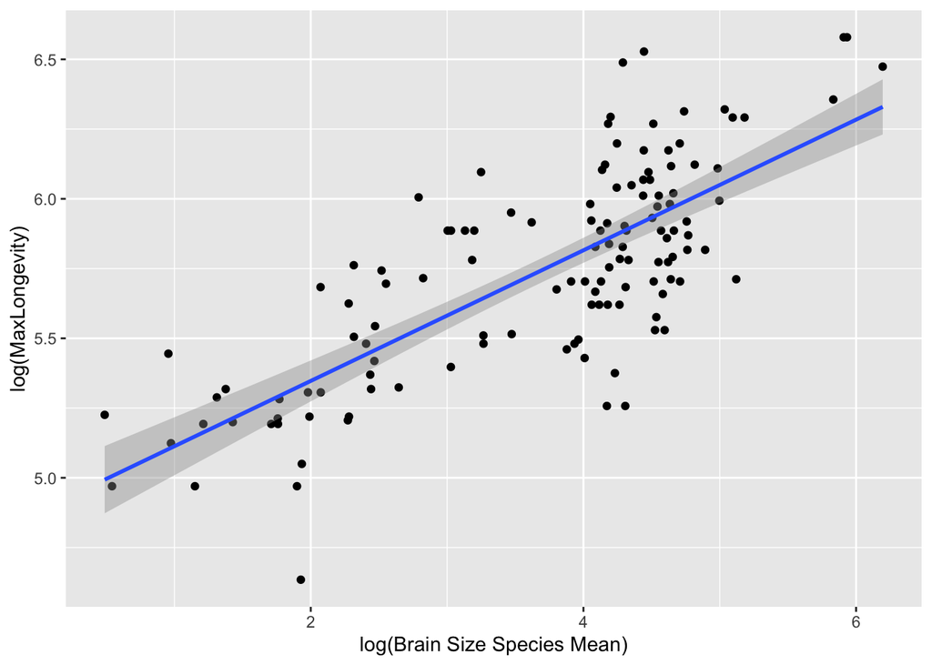

```r
p2 <- ggplot(data = k, aes(x = log(Brain_Size_Species_Mean), y = log(MaxLongevity_m)))
p2 <- p2 + xlab("log(Brain Size Species Mean)") + ylab("log(MaxLongevity)")
p2 <- p2 + geom_point()
p2 <- p2 + geom_smooth(method = "lm")
p2
```

## Aggregate Statistics and the {dplyr} Package

To calculate summary statistics for groups of observations in a data frame, there are many different approaches.

Can use aggregate() but it is more clunky

```r
aggregate(k$Body_mass_female_mean ~ k$Family, FUN = "mean", na.rm = TRUE)
```

```
##           k$Family k$Body_mass_female_mean
## 1         Atelidae               6616.2000
## 2          Cebidae                876.3323
## 3  Cercopithecidae               6327.8247
## 4    Cheirogalidae                186.0286
## 5    Daubentonidae               2490.0000
## 6        Galagidae                371.6143
## 7        Hominidae              53443.7167
## 8      Hylobatidae               6682.1200
## 9        Indriidae               3886.5333
## 10       Lemuridae               1991.1200
## 11   Lepilemuridae                813.5000
## 12       Lorisidae                489.8625
## 13     Pitheciidae               1768.5000
## 14       Tarsiidae                120.0000
```

So this gives us two columns and the mean of the numerical observations in those columns. It’s a little confusing in this one because it’s the mean of a column that is the mean but each observation is much more granular so it is averaging up each data point that belongs to atelidae, etc.

Another way of doing this with bracket notation:

```r
aggregate(x = k["Body_mass_female_mean"], by = k["Family"], FUN = "mean", na.rm = TRUE)
```

```
##             Family Body_mass_female_mean
## 1         Atelidae             6616.2000
## 2          Cebidae              876.3323
## 3  Cercopithecidae             6327.8247
## 4    Cheirogalidae              186.0286
## 5    Daubentonidae             2490.0000
## 6        Galagidae              371.6143
## 7        Hominidae            53443.7167
## 8      Hylobatidae             6682.1200
## 9        Indriidae             3886.5333
## 10       Lemuridae             1991.1200
## 11   Lepilemuridae              813.5000
## 12       Lorisidae              489.8625
## 13     Pitheciidae             1768.5000
## 14       Tarsiidae              120.0000
```

Or we can use dplyr functions

filter() requires entering the data, and the columns you are subsetting under what parameters with operators such as ==, > or <

```r
s <- filter(k, Family == "Hominidae" & Mass_Dimorphism > 2)
head(s)
```

```
##   Scientific_Name    Family   Genus  Species Brain_Size_Species_Mean
## 1 Gorilla_gorilla Hominidae Gorilla  gorilla                  490.41
## 2    Pongo_abelii Hominidae   Pongo   abelii                  389.50
## 3  Pongo_pygmaeus Hominidae   Pongo pygmaeus                  377.38
##   Brain_Size_Female_Mean   Brain_size_Ref Body_mass_male_mean
## 1                 455.89 Isler et al 2008            170400.0
## 2                 341.21 Isler et al 2008             84482.5
## 3                 337.72 Isler et al 2008             80136.9
##   Body_mass_female_mean Mass_Dimorphism         Mass_Ref MeanGroupSize
## 1               71500.0           2.383 Isler et al 2008           7.1
## 2               41148.0           2.053 Isler et al 2008            NA
## 3               36947.6           2.169 Isler et al 2008           2.0
##   AdultMales AdultFemale AdultSexRatio
## 1        1.8         4.4          2.44
## 2         NA          NA            NA
```

[output cut: 29 more lines]

arrange() orders the rows of the data frame by the values of selected columns.

So first we have all of Atelidae arranged then genus Alouatta then body mass increasing; then it would go to the next. (I think this is how it works based on the documentation but I am a little unclear).

```r
s <- arrange(k, Family, Genus, Body_mass_male_mean)
head(s)
```

```
##      Scientific_Name   Family    Genus   Species Brain_Size_Species_Mean
## 1   Alouatta_guariba Atelidae Alouatta   guariba                   51.70
## 2    Alouatta_caraya Atelidae Alouatta    caraya                   52.63
## 3 Alouatta_seniculus Atelidae Alouatta seniculus                   55.22
## 4  Alouatta_palliata Atelidae Alouatta  palliata                   49.88
## 5  Alouatta_belzebul Atelidae Alouatta  belzebul                   52.84
## 6     Alouatta_pigra Atelidae Alouatta     pigra                   51.13
##   Brain_Size_Female_Mean   Brain_size_Ref Body_mass_male_mean
## 1                  49.08 Isler et al 2008                5800
## 2                  47.80 Isler et al 2008                6525
## 3                  54.26 Isler et al 2008                6690
## 4                  48.04 Isler et al 2008                7150
## 5                  51.19 Isler et al 2008                7270
## 6                  48.75 Isler et al 2008               11400
##   Body_mass_female_mean Mass_Dimorphism         Mass_Ref MeanGroupSize
```

[output cut: 62 more lines]

select() just lets you see those columns

```r
s <- select(k, Family, Genus, Body_mass_male_mean)  # selecting specific columns...
head(s)
```

```
##            Family          Genus Body_mass_male_mean
## 1 Cercopithecidae Allenopithecus                6130
## 2 Cercopithecidae      Allocebus                  92
## 3        Atelidae       Alouatta                7270
## 4        Atelidae       Alouatta                6525
## 5        Atelidae       Alouatta                5800
## 6        Atelidae       Alouatta                7150
```

rename() lets you rename columns

```r
s <- rename(k, Female_Mass = Body_mass_female_mean)
head(s$Female_Mass)
```

```
## [1] 3180   84 5520 4240 4550 5350
```

mutate() adds new variables that are functions of old variables

This one is turning genus and species (first turned into character vectors separated by spaces) into a column called binomial. It is reading across the data frame).

```r
s <- mutate(k, Binomial = paste(Genus, Species, sep = " "))
head(s$Binomial)
```

```
## [1] "Allenopithecus nigroviridis" "Allocebus trichotis"
## [3] "Alouatta belzebul"           "Alouatta caraya"
## [5] "Alouatta guariba"            "Alouatta palliata"
```

summarise() is a simpler aggregate()

This is taking data frame k, and under the column name avgF giving the mean of all of the column body mass female mean, excluding NA values, then doing the same for males (under a column avgM).

```r
s <- summarise(k, avgF = mean(Body_mass_female_mean, na.rm = TRUE), avgM = mean(Body_mass_male_mean, na.rm = TRUE))
s
```

```
##       avgF     avgM
## 1 5396.474 8111.801
```

group_by() allows a data frame to be grouped by a column value

```r
byFamily <- group_by(k, Family)
byFamily
```

```
## # A tibble: 213 × 44
## # Groups:   Family [14]
##    Scientific_Name             Family       Genus Species Brain_Size_Species_M…¹
##    <chr>                       <chr>        <chr> <chr>                    <dbl>
##  1 Allenopithecus_nigroviridis Cercopithec… Alle… nigrov…                   58.0
##  2 Allocebus_trichotis         Cercopithec… Allo… tricho…                   NA
##  3 Alouatta_belzebul           Atelidae     Alou… belzeb…                   52.8
##  4 Alouatta_caraya             Atelidae     Alou… caraya                    52.6
##  5 Alouatta_guariba            Atelidae     Alou… guariba                   51.7
##  6 Alouatta_palliata           Atelidae     Alou… pallia…                   49.9
##  7 Alouatta_pigra              Atelidae     Alou… pigra                     51.1
##  8 Alouatta_seniculus          Atelidae     Alou… senicu…                   55.2
##  9 Aotus_azarai                Cebidae      Aotus azarai                    20.7
## 10 Aotus_brumbacki             Cebidae      Aotus brumba…                   NA
## # ℹ 203 more rows
## # ℹ abbreviated name: ¹Brain_Size_Species_Mean
## # ℹ 39 more variables: Brain_Size_Female_Mean <dbl>, Brain_size_Ref <chr>,
## #   Body_mass_male_mean <dbl>, Body_mass_female_mean <dbl>,
## #   Mass_Dimorphism <dbl>, Mass_Ref <chr>, MeanGroupSize <dbl>,
## #   AdultMales <dbl>, AdultFemale <dbl>, AdultSexRatio <dbl>,
## #   Social_Organization_Ref <chr>, InterbirthInterval_d <dbl>, …
```

Then we can summarise the grouped variable

```r
s <- summarise(byFamily, avgF = mean(Body_mass_female_mean, na.rm = TRUE), avgM = mean(Body_mass_male_mean,
    na.rm = TRUE))
s
```

```
## # A tibble: 14 × 3
##    Family            avgF   avgM
##    <chr>            <dbl>  <dbl>
##  1 Atelidae         6616.  7895.
##  2 Cebidae           876.  1012.
##  3 Cercopithecidae  6328.  9543.
##  4 Cheirogalidae     186.   193.
##  5 Daubentonidae    2490   2620
##  6 Galagidae         372.   395.
##  7 Hominidae       53444. 98681.
##  8 Hylobatidae      6682.  6926.
##  9 Indriidae        3887.  3638.
## 10 Lemuridae        1991.  2077.
## 11 Lepilemuridae     814.   792
## 12 Lorisidae         490.   512.
## 13 Pitheciidae      1768.  1955.
## 14 Tarsiidae         120    131
```

So now this looks a lot like a cleaner version of aggregate()

## Piping

%>% is an operator that moves operations together. Whatever comes after is implemented before. It saves lines of code and produces more complicated outputs. Basically whatever is directly before the pipe, is the first argument in the function that immediately comes after the pipe.

This is the last few lines of code as one line using pipes:

```r
s <-                                                             #to create dataframe "s"
  k %>%                                                          #take dataframe "k"
  group_by(Family) %>%                                           #Group it by Family (usually this would be group_by(k, Family))
  summarise(avgF = mean(Body_mass_female_mean, na.rm=TRUE),      #And calculate mean male BM
            avgM = mean(Body_mass_male_mean, na.rm=TRUE))        #And mean female BM (and usually this would be summarise(byFamily, etc))
s
```

```
## # A tibble: 14 × 3
##    Family            avgF   avgM
##    <chr>            <dbl>  <dbl>
##  1 Atelidae         6616.  7895.
##  2 Cebidae           876.  1012.
##  3 Cercopithecidae  6328.  9543.
##  4 Cheirogalidae     186.   193.
##  5 Daubentonidae    2490   2620
##  6 Galagidae         372.   395.
##  7 Hominidae       53444. 98681.
##  8 Hylobatidae      6682.  6926.
##  9 Indriidae        3887.  3638.
## 10 Lemuridae        1991.  2077.
## 11 Lepilemuridae     814.   792
## 12 Lorisidae         490.   512.
## 13 Pitheciidae      1768.  1955.
## 14 Tarsiidae         120    131
```

And voila we get the same thing!

### Challenge 8

In one line of code, do the following:

Add a variable, Binomial to our data frame k, which is a concatenation of the Genus and Species… Trim the data frame to only include the variables Binomial, Family, Body_mass_female_mean, Body_mass_male_mean and Mass_Dimorphism… Group these by Binomial (in other words, by species but with full binomial nomenclature)… And calculate the average value for female body mass, male body mass, and mass dimorphism.

```r
s <- k %>% mutate(Binomial = paste(Genus, Species, sep = " ")) %>% select(Binomial, Family, Body_mass_female_mean, Body_mass_male_mean, Mass_Dimorphism) %>% group_by(Binomial) %>% summarise(avgF = mean(Body_mass_female_mean, na.rm = TRUE), avgM = mean(Body_mass_male_mean,
    na.rm = TRUE), avgD = mean(Mass_Dimorphism, na.rm = TRUE))
s
```

```
## # A tibble: 213 × 4
##    Binomial                     avgF  avgM    avgD
##    <chr>                       <dbl> <dbl>   <dbl>
##  1 Allenopithecus nigroviridis  3180  6130   1.93
##  2 Allocebus trichotis            84    92   1.10
##  3 Alouatta belzebul            5520  7270   1.32
##  4 Alouatta caraya              4240  6525   1.54
##  5 Alouatta guariba             4550  5800   1.27
##  6 Alouatta palliata            5350  7150   1.34
##  7 Alouatta pigra               6430 11400   1.77
##  8 Alouatta seniculus           5210  6690   1.28
##  9 Aotus azarai                 1230  1180   0.959
## 10 Aotus brumbacki               NaN   NaN NaN
## # ℹ 203 more rows
```

```r
## s %>% filter(Binomial == "Chlorocebus pygerythrus" | "Lagothrix lagotricha")
```

Acccording to Kamilar & Cooper’s (2013) dataset, what is the average male and female size, and body mass dimorphism of my two main study species (vervet monkeys, Chlorocebus pygerythrus; and woolly monkeys, Lagothrix lagotricha)?

**Chlorocebus pygerythrus: Female: 3575.8 Male: 5071.2 Dimorphism: 1.418** **Lagothrix lagotricha: Female: 7020.0 Male: 7280.0 Dimorphism: 1.037**

Which has a larger average female body mass?

**Lagothrix lagotricha**

Which is more sexually dimorphic?

**Chlorocebus pygerythrus**

Compare the body size of my two main study taxa at the Family level (i.e., Cercopithecidae vs. Atelidae) by plotting (using {ggplot2}) the body mass of males and females and sexual dimorphism. If you can, make the Cercopithecid boxes green, and the Atelid boxes purple.

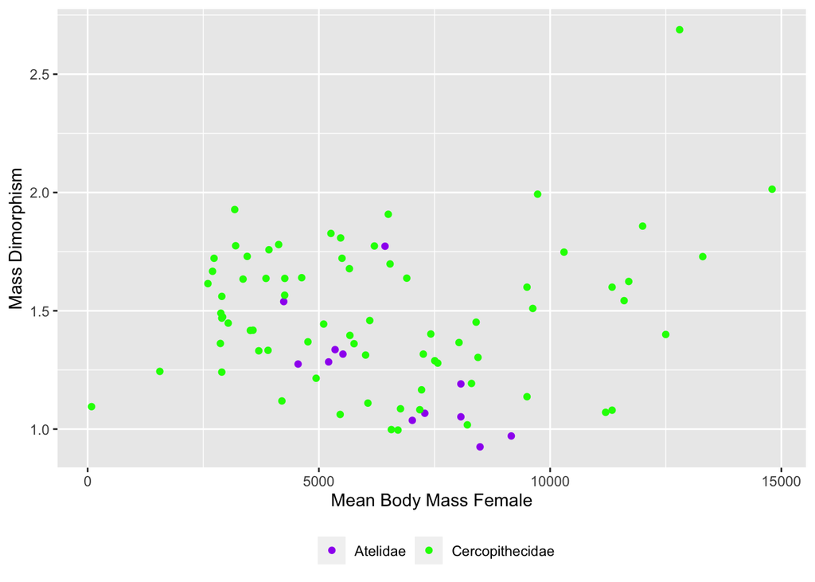

```r
monkeys <- filter(k, Family == "Cercopithecidae" | Family == "Atelidae")
par(mfrow = c(1, 2))
p3 <- ggplot(data = monkeys, aes(x = Body_mass_female_mean, y = Mass_Dimorphism, color = factor(Family)))
p3 <- p3 + xlab("Mean Body Mass Female") + ylab("Mass Dimorphism")
p3 <- p3 + geom_point()
p3 <- p3 + theme(legend.position = "bottom", legend.title = element_blank())
p3 <- p3 + scale_color_manual(breaks = c("Atelidae", "Cercopithecidae"), values = c("purple", "green"))
p3
```

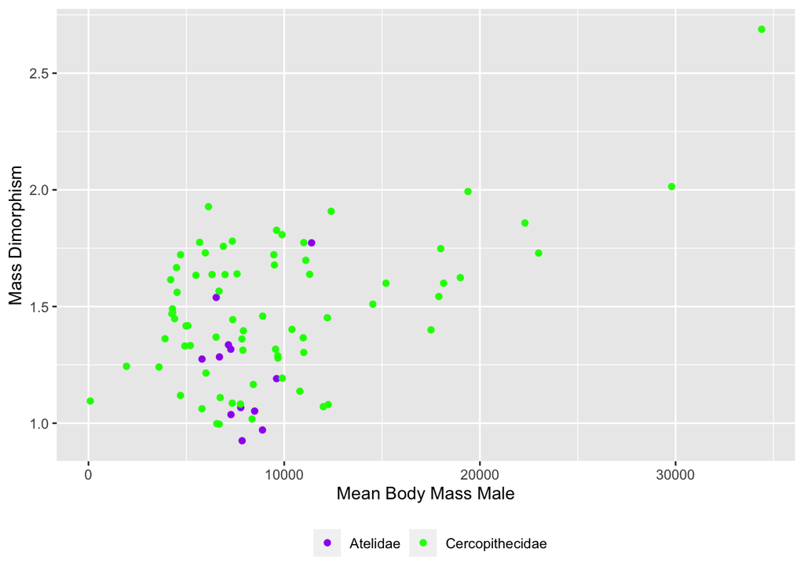

```r
p4 <- ggplot(data = monkeys, aes(x = Body_mass_male_mean, y = Mass_Dimorphism, color = factor(Family)))
p4 <- p4 + xlab("Mean Body Mass Male") + ylab("Mass Dimorphism")
p4 <- p4 + geom_point()
p4 <- p4 + theme(legend.position = "bottom", legend.title = element_blank())
p4 <- p4 + scale_color_manual(breaks = c("Atelidae", "Cercopithecidae"), values = c("purple", "green"))
p4
```

This is where I found how to change the colors: http://www.sthda.com/english/wiki/ggplot2-colors-how-to-change-colors-automatically-and-manually#:~:text=%2C%20c%20%3D%20100.-,Change%20colors%20manually,()%20for%20lines%20and%20points

```r
## From class 9/21/2023 another go
byFamilyCA <- filter(k, Family == "Cercopithecidae" | Family == "Atelidae")
byFamilyCA
```

[output not shown]

[output cut: 1181 more lines]

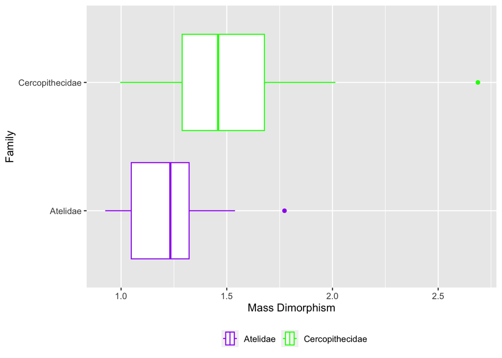

```r
p3 <- ggplot(data = byFamilyCA, aes(x = Mass_Dimorphism, y = Family, color = factor(Family)))
p3 <- p3 + xlab("Mass Dimorphism") + ylab("Family")
p3 <- p3 + geom_boxplot()
p3 <- p3 + theme(legend.position = "bottom", legend.title = element_blank())
p3 <- p3 + scale_color_manual(breaks = c("Atelidae", "Cercopithecidae"), values = c("purple", "green"))
p3
```

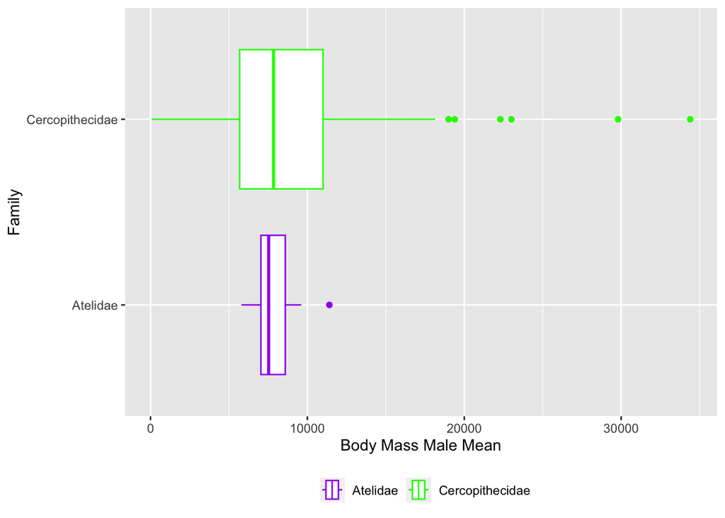

```r
p4 <- ggplot(data = byFamilyCA, aes(x = Body_mass_male_mean, y = Family, color = factor(Family)))
p4 <- p4 + xlab("Body Mass Male Mean") + ylab("Family")
p4 <- p4 + geom_boxplot()
p4 <- p4 + theme(legend.position = "bottom", legend.title = element_blank())
p4 <- p4 + scale_color_manual(breaks = c("Atelidae", "Cercopithecidae"), values = c("purple", "green"))
p4
```

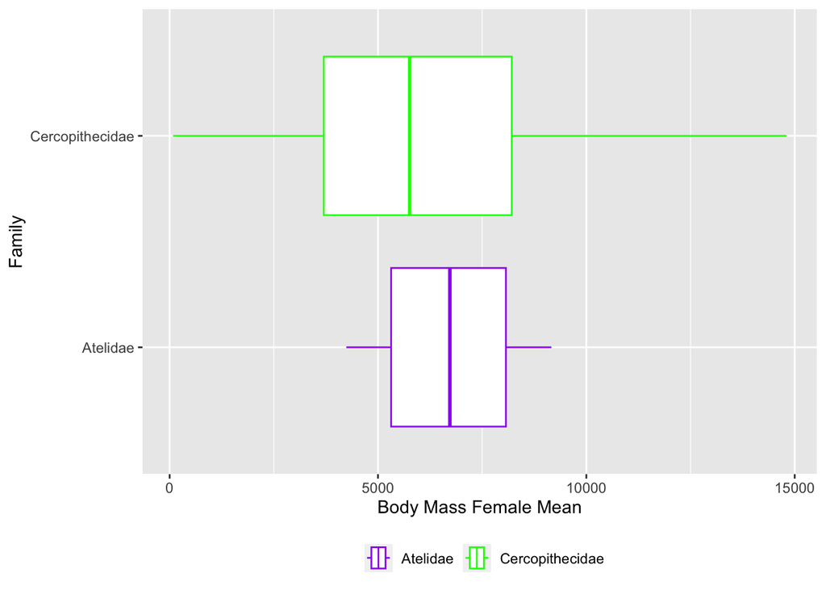

```r
p5 <- ggplot(data = byFamilyCA, aes(x = Body_mass_female_mean, y = Family, color = factor(Family)))
p5 <- p5 + xlab("Body Mass Female Mean") + ylab("Family")
p5 <- p5 + geom_boxplot()
p5 <- p5 + theme(legend.position = "bottom", legend.title = element_blank())
p5 <- p5 + scale_color_manual(breaks = c("Atelidae", "Cercopithecidae"), values = c("purple", "green"))
p5
```